# 4 Fish

Published

April 10, 2025

This document defines and creates the authoritative fish taxa lookup table for the Pristine Seas Database. The `taxa_luts.fish` table integrates species codes used during field surveys with validated taxonomic information and ecological traits. It supports QA/QC, data integration, and biodiversity analyses across expeditions and methods.

The table builds on the foundational metaanalysis work of Akiona et al. (in prep.) at the Scripps Institution of Oceanography, who compiled life history parameters for Pacific coral reef fishes—including trophic groups and length-weight relationships for species commonly observed at fore reef sites (~10 m depth) across 13 countries.

We complement this dataset with field observations from underwater visual surveys conducted by divers during Pristine Seas expeditions. We use the World Register of Marine Species (WoRMS) to validate taxonomy, assign AphiaIDs, and standardize scientific names. Additional ecological and life history traits—including maximum total length, trophic level, and length-weight parameters—are sourced from FishBase and updated with regional data where available.

## Table Structure

### Core identifiers

These essential fields are used to identify and validate each fish taxon across Pristine Seas datasets (Table 4.1). Each row in the `taxa_luts.fish` table is uniquely identified by a `taxon_code`, which links raw field observations to validated taxonomic names and external databases such as WoRMS and FishBase.

This schema captures both the field-level identity (what was recorded by divers) and the accepted scientific name (according to WoRMS), allowing for traceability, reconciliation of legacy codes, and global interoperability.

Table 4.1: Primary identifiers for fish taxa in the Pristine Seas Database

| name | type | description |
| --- | --- | --- |
| taxon_code | STRING | Pristine Seas field code. Unique, mnemonic identifier used in data collection. |
| taxon | STRING | Original name associated with the taxon code (may be outdated, informal, or partial). |
| rank | STRING | Taxonomic rank of the name (e.g., species, genus, family). |
| aphia_id | INTEGER | WoRMS AphiaID corresponding to the input name. |
| name_status | STRING | Taxonomic status of the input name according to WoRMS (e.g., accepted, synonym, deleted). |
| accepted_name | STRING | Currently accepted scientific name according to WoRMS. |
| accepted_aphia_id | INTEGER | WoRMS AphiaID for the accepted name. |
| fishbase_id | INTEGER | FishBase SpecCode identifier, used for trait and distribution data. |

#### `taxon_code`

**🧠 Code Format**

For species-level identifications, `taxon_code` follows the default format:

GEN2.SPEC4

- `GEN2`: First two letters of the genus (uppercase)
- `SPEC4`: First four letters of the species (uppercase)

**Examples**

- *Acanthurus tristis* → `AC.TRIS`
- *Apogon tricolor* → `AP.TRIC`
- *Anthias tricolor* → `AN.TRIC`

**🔄 Duplicates Handling**

If two or more species would generate the same`taxon_code`, we resolve the conflict deterministically by retaining the original code for the most frequently observed taxon. For all others, we extend either the genus or species portion of the code to ensure uniqueness, following a consistent set of rules.

**If the genus is different**  
Extend the genus portion:

- *Apogon tristis* → `AP.TRIS`
- *Aplodactylus tristis* → `APL.TRIS`

**If the genus is the same**  
Extend the species portion:

- *Labroides bicolor* → `LA.BICO`
- *Labroides bilineatus* → `LA.BILI`
- *Labroides bilinearis* → `LA.BILIN`

> ⚠️ Duplicate resolution only applies when the full code already exists.

**🔍 Genus- and Family-Level Identifications**

When taxa are not identified to species level, use the following formats:

- **Genus-level** → `GEN4.SP`  
  *Labroides* sp. → `LABR.SP`
- **Family-level** → `FAM4.SPP`  
  *Labridae* spp. → `LABR.SPP`

### Taxonomic Lineage

Table 4.2: Taxonomic lineage fields for fish taxa in the Pristine Seas Database

| name | type | description |
| --- | --- | --- |
| genus | STRING | Genus of the accepted name. |
| family | STRING | Family of the accepted name. |
| order | STRING | Order of the accepted name. |
| class | STRING | Class of the accepted name. |
| phylum | STRING | Phylum of the accepted name. |
| kingdom | STRING | Kingdom of the accepted name. |

### Common Names

These fields store standardized English common names at both the species and family levels (Table 4.3). Common names are used for reporting, visualizations, and communication with non-specialist audiences, including community stakeholders and policymakers. Values are drawn from mainly from FishBase and filling in with internal knowledge. This is juist a reference. Local common names will change place by place and should be used when possible.

| name | type | description |
| --- | --- | --- |
| common_name | STRING | Primary English common name for the species, standardized across sources. |
| common_family | STRING | Common name for the family (e.g., wrasses, groupers), used for broader summaries. |

### Morphological Traits

These fields capture key length and weight traits for fish species, used in ecological modeling, biomass estimation, and life history comparisons (Table 4.4). All values are standardized to total length (TL). Sources include FishBase, SIO datasets, and field observations.

Table 4.4: Maximum length and conversion parameters for fish taxa in the Pristine Seas Database

| name | type | description |
| --- | --- | --- |
| tl_max | FLOAT | Maximum total length (TL) in cm. |
| tl_max_source | STRING | Source of max length (e.g., FishBase, SIO, field observation). |
| lw_a | FLOAT | Coefficient 'a' in length-weight relationship: W = a × L^b. |
| lw_b | FLOAT | Exponent 'b' in length-weight relationship: W = a × L^b. |
| ltl_ratio | FLOAT | Length-to-length conversion ratio (if needed, e.g., SL to TL). |
| lw_length_type | STRING | Type of length used in length-weight relationship (e.g., TL, SL). |
| lw_source | STRING | Source of length-weight parameters (e.g., FishBase, SIO, published study). |

### Habitat

The habitat_zone field describes the typical vertical or spatial habitat each species occupies in the marine environment. It supports biogeographic summaries, trait-based modeling, and understanding species associations with survey methods. Habitat classifications are drawn from FishBase (“demers_pelag”).

Table 4.5: Habitat zone for fish taxa in the Pristine Seas Database

| name | type | description |
| --- | --- | --- |
| habitat_zone | STRING | Spatial habitat classification from FishBase. One of: 'reef-associated', 'benthopelagic', 'demersal', 'pelagic', 'pelagic-neritic', 'pelagic-oceanic', 'bathypelagic', 'bathydemersal', 'unknown'. |

### Trophic Traits

The trophic_traits fields describe the energetic role and feeding strategy of each fish taxon (Table 4.6). These traits are essential for food web analysis, functional group classification, and ecosystem-based assessments. Values are primarily sourced from FishBase and Akiona et al., 2025.

Table 4.6: Trophic traits for fish taxa in the Pristine Seas Database

| name | type | description |
| --- | --- | --- |
| trophic_group | STRING | Broad ecological category based on diet and position in food web,One of: herbivore/detritivore, planktivore, lower-carnivore, top-predator, shark |
| trophic_lvl | FLOAT | Estimated numeric trophic level (from FishBase) |
| trophic_lvl_se | FLOAT | Standard error of the trophic level estimate |
| feeding_path | STRING | Dominant foraging environment (from FishBase) |
| feeding_type | STRING | Behavioral feeding strategy (from FishBase) |
| diet | STRING | Combined dietary category (from FishBase) |

### Fisheries use

The `fisheries_use` field indicates the level of importance each species holds for commercial or subsistence fisheries. This trait is critical for conservation planning, fisheries impact assessments, and identifying species of cultural or economic value. Values are sourced from the `importance` field in FishBase and complemented with internal knolwedge.

Table 4.7: Fisheries use classification for fish taxa in the Pristine Seas Database

| name | type | description |
| --- | --- | --- |
| fisheries_use | STRING | FishBase classification of the species' importance to fisheries (e.g., 'minor commercial', 'subsistence fisheries', 'highly commercial', 'of no interest'). |

## Overview

Our database has excellent coverage for all core identity fields, including taxonomy and length-weight parameters. However, we still have work to do to fill gaps in trophic traits, habitat associations, and fisheries importance (Figure 4.1).

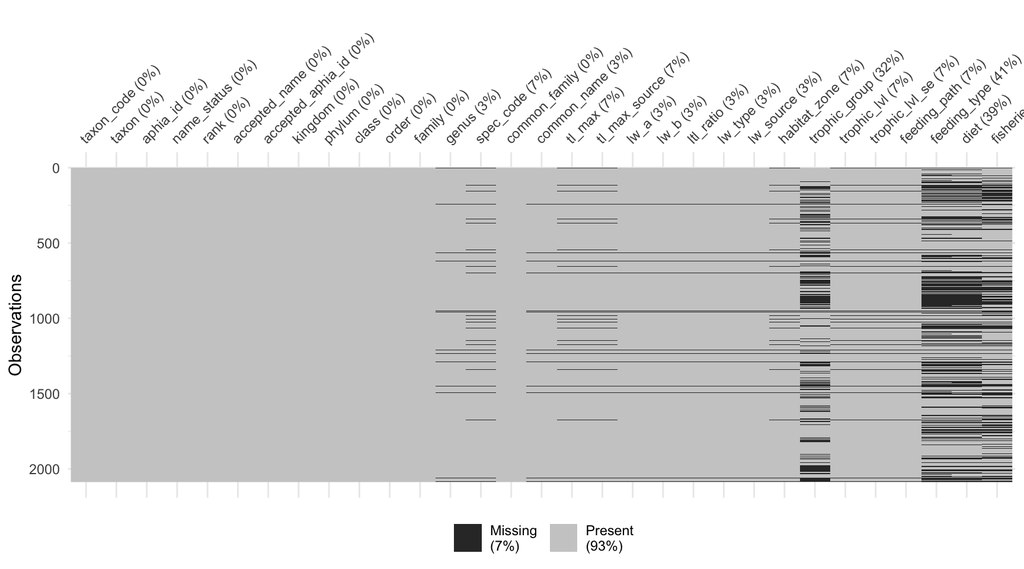

Figure 4.1: Missingness in the fish taxa lookup table

[interactive chart not shown]

Figure 4.2: Number of species by order and family

The best represented families include (Figure 4.3):

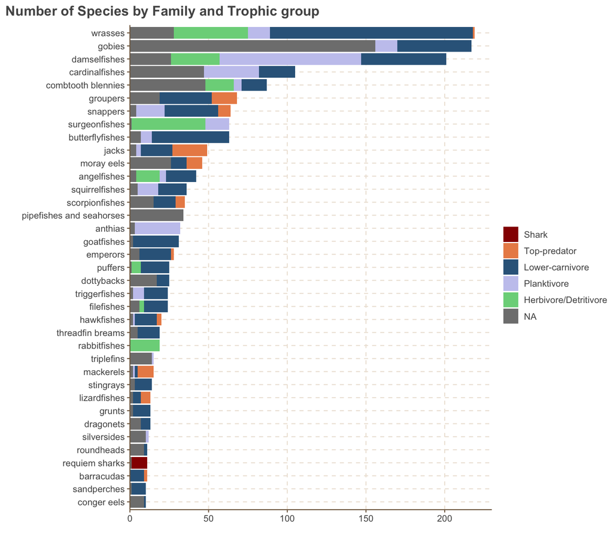

Figure 4.3: Number of species by common family and trophic group

Most species in the dataset are classified as Lower-carnivores, with 757 species, followed by 283 planktivores and 205 herbivores/detritivores. The dataset also includes 103 top predators—such as groupers, snappers, and jacks—and 14 sharks.

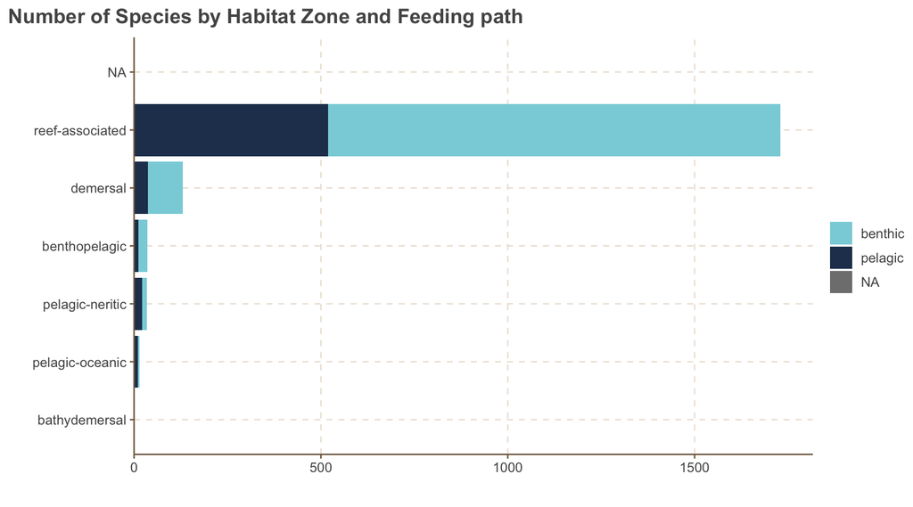

Figure 4.4: Number of species by habitat zone and feeding path

Most species in the dataset are classified as reef-associated with a primarily benthic feeding pathway (Figure 4.4). Additionally, according to FishBase, the majority of species have some level of importance to humans, whether for subsistence or commercial purposes (Figure 4.5).

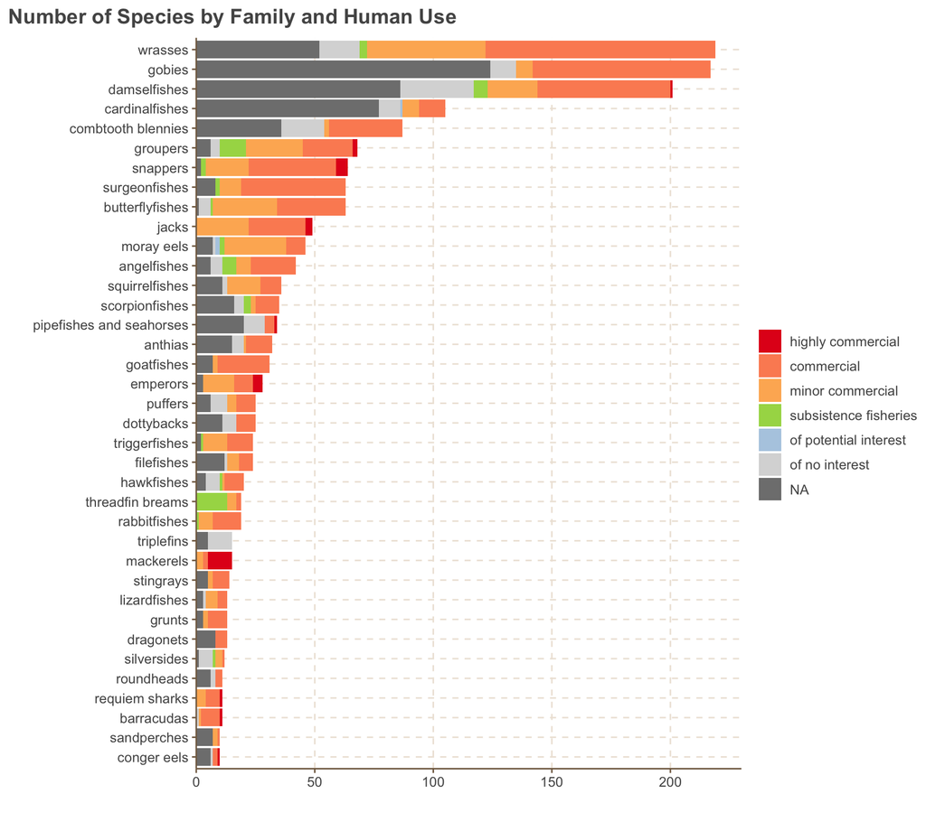

Figure 4.5: Number of species by family and human use